# 1. Pre-processing data

David Innes

This whole analysis requires a data frame with only the following columns:

1. `Cow` - cow’s number identification
2. `Parity` - number representing what parity the lactation represents
3. `ID` - lactation ID in the format: Cow_Parity (This can be added here using `mutate()` and `str_c()`)
4. `DIM` - days in milk; d
5. `my` - milk yield; kg

Step 1 (in this file) has 3 main steps:

1. clean data - described in function: `f_clean_lac_data.R`
2. describe data - `f_descriptive_stats.R`
3. summarise lactation data - `f_summary_tables.R`

```r
suppressPackageStartupMessages(library(tidyverse))
library(slider)

# load required functions:
source("./functions/f_clean_lac_data.R")
source("./functions/f_descriptive_stats.R")
source("./functions/f_summary_tables.R")
```

# Import

```r
# Import file
workingfile <- data.table::fread("./Inputs/simulated_exlac_data.csv") %>%
  #rename column to match requirements of scripts:
  rename(Cow = cow_ID)

glimpse(workingfile)
```

[output not shown]

# a) Data cleaning

## Execute cleaning steps

```r
# generate_plots = FALSE prevents individual lactation plots from being generated.
list_output <- f_clean_lac_data(workingfile, generate_plots = TRUE)
```

## Print log

Because this is a synthetic dataset, various errors are not detected here.

```r
list_output$log$Step1_NA_removed
```

| ID | Cow | Parity | DIM | my |
| --- | --- | --- | --- | --- |
| 0 | 0 | 0 | 0 | 0 |

```r
list_output$log[-1]
```

```
$IDs_bad_DIM
character(0)

$`PRE-FILTER - Number Unique Cows`
[1] 90

$`PRE-FILTER - Number Unique Lactations`
[1] 90

$`1st-FILTER: Number Unique Cows`
[1] 85

$`1st-FILTER: Number Unique Lactations`
[1] 85

$`1st-FILTER: Number rows`
[1] 29494

$`MID-Lac Gap: mid_lac_break_IDs`
[1] "1100_4" "1463_6" "1704_7" "1965_2"

$`MID-Lac Gap: n_lactations_removed_mid_lac_break`
[1] 4

$`GAP-FILTER: n_rows_pre-gap-filter`
[1] 29494

$`GAP-FILTER: n_rows_removed >=305 DIM`
```

| DIM_flag_reporting | n |
| --- | --- |
| FALSE | 1450 |
| TRUE | 4 |
| NA | 28040 |

```
$`MID-Lac GAP-FILTER: n_rows_removed mid lac break > 14 d`
[1] 1280

$`GAP-FILTER: Number Unique Cows`
[1] 81

$`GAP-FILTER: Number Unique Lactations`
[1] 81

$`GAP-FILTER: n_rows_post-gap-filter`
[1] 28210

$`RE-FILTER: Number Unique Cows`
[1] 81

$`RE-FILTER: Number Unique Lactations`
[1] 81

$`RE-FILTER: n_rows post-re-filter`
[1] 28210

$`OUTLIER DETECTION: n_rows_pre_filter`
[1] 28210

$`OUTLIER DETECTION: n_rows_post_filter`
[1] 28091
```

## Diagnostic Plots

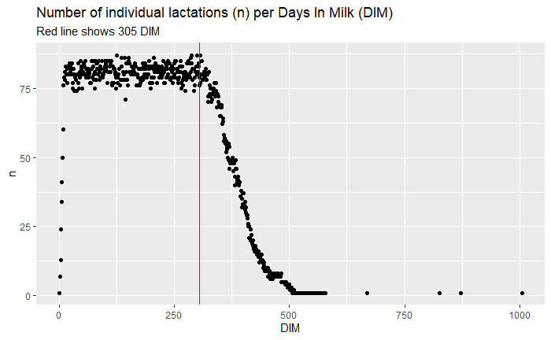

```r
list_output$plots$n_per_DIM_prefilter
```

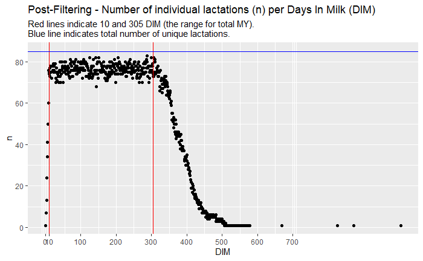

```r
list_output$plots$n_per_DIM_postfilter
```

### Plot of lactations removed with break mid-lac

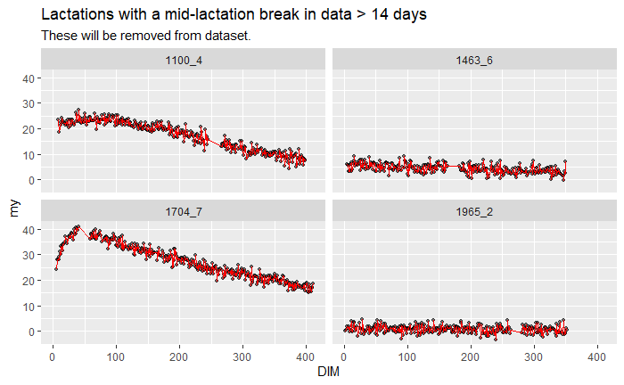

```r
list_output$plots$lacs_mid_break_REMOVED
```

## Example of output plots

```r
# Only works if generate_plots = TRUE
list_output$plots$list_gap_classification_plots$`1035_2`

list_output$plots$list_outlier_detection_plots$`1705_3`
```

[output not shown]

## Save plots

This can take a while, and is better executed on a powerful computer.

```r
# Only works if generate_plots = TRUE


f_plot <- function(.x, .y){
  plot_in <- .x
  name_in <- .y

  p <- ggsave(filename = paste0("outlier_plot_",name_in,".png"),
              path = "./Plots/Outlier_Detection/",
              plot =  plot_in,
              dpi = 150,
              width=10,
              height=7)
}

list_to_plot <- list_output$plots$list_outlier_detection_plots[1:3]
#list_to_plot <- list_output$plots$list_gap_classification_plots[1:3]

map2(.x = list_to_plot, .y = names(list_to_plot), .f = f_plot )
```

## OUTPUT total_MY_summary

This is required for downstream analysis, so save here. Saving files as .rds is much quicker and preserves some formatting.

```r
# Save cleaned_data.
saveRDS(list_output$cleaned_data, "./Outputs/cleaned_data_out.rds")

data.table::fwrite(list_output$total_MY_summary, "./Outputs/total_MY_summary_out.csv")
saveRDS(list_output$total_MY_summary, "./Outputs/total_MY_summary_out.rds")
```

# b) Summary Descriptive Stats

This function summarises the data to match output for Table 1 in publication.

```r
(df_descriptive_stats_FULL <-
  f_descriptive_stats(cleaned_data_in = list_output$cleaned_data)
 )
```

```
[1] "Number of cows: 81"
[1] "Number of complete lactations (> 305 DIM): 81"
```

[output not shown]

[output cut: 8 more lines]

# c) Summarise characteristics of lactation

```r
(parity_summary <- f_summary_tables(list_output$cleaned_data,
                   list_output$total_MY_summary,
                   to_group_by = Parity_class))
```

| name | Primiparous | Multiparous |
| --- | --- | --- |
| n | 25.00 | 56.00 |
| mean_lac_length_d | 397.60 | 389.95 |
| sd_lac_length_d | 51.84 | 48.00 |
| mean_total_305d_my_kg | 9621.84 | 8275.93 |
| sd_total_305d_my_kg | 3796.11 | 3410.31 |
| mean_305d_my_kg | 25.47 | 17.87 |
| sd_305d_my_kg | 11.11 | 8.74 |
| mean_MY_kg_d | 30.04 | 24.95 |
| sd_MY_kg_d | 13.64 | 13.27 |

```r
# view only means
#parity_summary %>% filter(str_detect(name, 'mean'))
```

## by Lactation length

```r
(lac_len_summary <- f_summary_tables(list_output$cleaned_data,
                   list_output$total_MY_summary,
                   to_group_by = Lac_len_group))
```

| name | Group1 | Group2 |
| --- | --- | --- |
| n | 47.00 | 34.00 |
| mean_lac_length_d | 359.91 | 437.09 |
| sd_lac_length_d | 22.28 | 39.65 |
| mean_total_305d_my_kg | 8922.33 | 8372.02 |
| sd_total_305d_my_kg | 3685.73 | 3419.88 |
| mean_305d_my_kg | 20.53 | 19.78 |
| sd_305d_my_kg | 10.22 | 10.06 |
| mean_MY_kg_d | 28.36 | 24.48 |
| sd_MY_kg_d | 13.77 | 13.10 |

```r
#lac_len_summary %>% filter(str_detect(name, 'mean'))
```

# OUTPUT tables to excel

Save an excel file with different outputs in each sheet to the `Outputs/` folder.

```r
# add to named list. Names = sheet names in excel output
tables_out_list <-
  list(df_descriptive_stats_FULL = df_descriptive_stats_FULL,
     parity_summary = parity_summary,
     lac_len_summary = lac_len_summary
     )

# adds a timestamp to filename:
openxlsx::write.xlsx(tables_out_list,
                     file = paste0("./Outputs/lac_summary_tables ",
                                   format(Sys.time(), "%Y%m%d_%H%M") ,
                                   ".xlsx"),
                     colWidths = "auto")
#
```